# R Portfolio

谢润兰

2026-05-08

# 根系性状与氮吸收速率

```r
library(readxl)
library(dplyr)
library(ggplot2)
root <- read_excel("./Data/root.xlsx")
root <- root[,-2]
head(root)
```

```
# A tibble: 6 × 6
  species AvgDiam_log RTD_log SRL_log SRA_log NUR_log
  <chr>         <dbl>   <dbl>   <dbl>   <dbl>   <dbl>
1 Pse          -0.151  -0.443   0.850    2.20   -2.86
2 Pse          -0.155  -0.501   0.917    2.26   -3.00
3 Pse          -0.166  -0.393   0.831    2.16   -2.72
4 Pse          -0.199  -0.394   0.894    2.19   -2.81
5 Pse          -0.175  -0.377   0.834    2.16   -2.67
6 Pse          -0.161  -0.341   0.766    2.10   -1.61
```

```r
root$species <- as.factor(root$species)
```

### 比较氮吸收速率的种间差异

```r
#单因素方差分析
aov_model <- aov(NUR_log ~ species, data = root)
summary(aov_model)
```

```
            Df Sum Sq Mean Sq F value Pr(>F)
species      1  0.131  0.1309   1.016  0.322
Residuals   28  3.608  0.1289
```

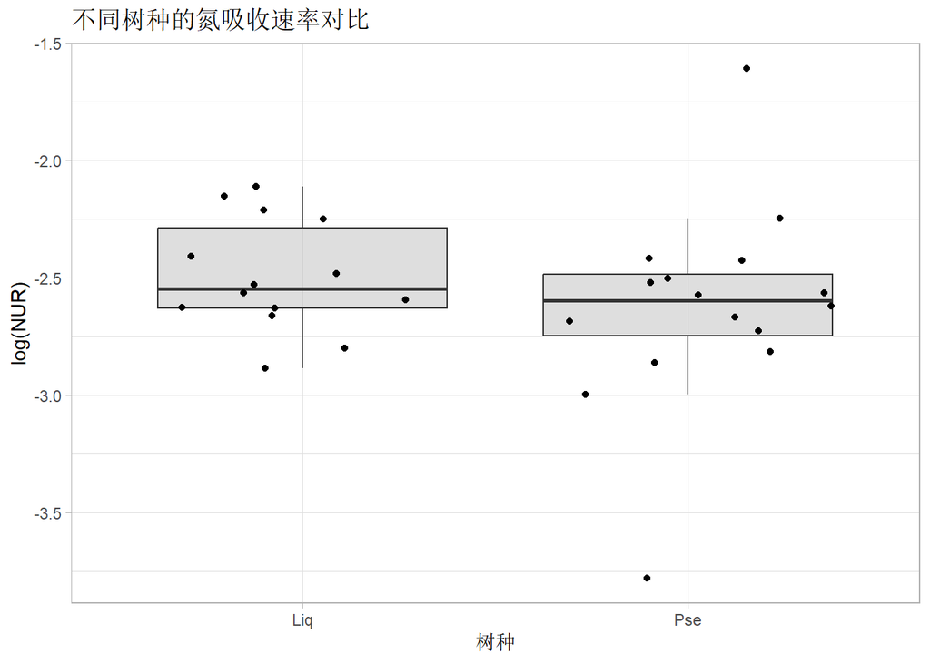

```r
#箱线图
ggplot(root, aes(x = species, y = NUR_log)) +
  geom_boxplot(fill="gray",alpha=0.5,outlier.shape = NA) +
  geom_jitter() +
  labs(title = "不同树种的氮吸收速率对比", y = "log(NUR)", x = "树种") +
  theme_light()
```

两个树种之间的氮吸收速率无显著差异（p>0.05），分布重叠多。

### 比较根系形态指标的种间差异

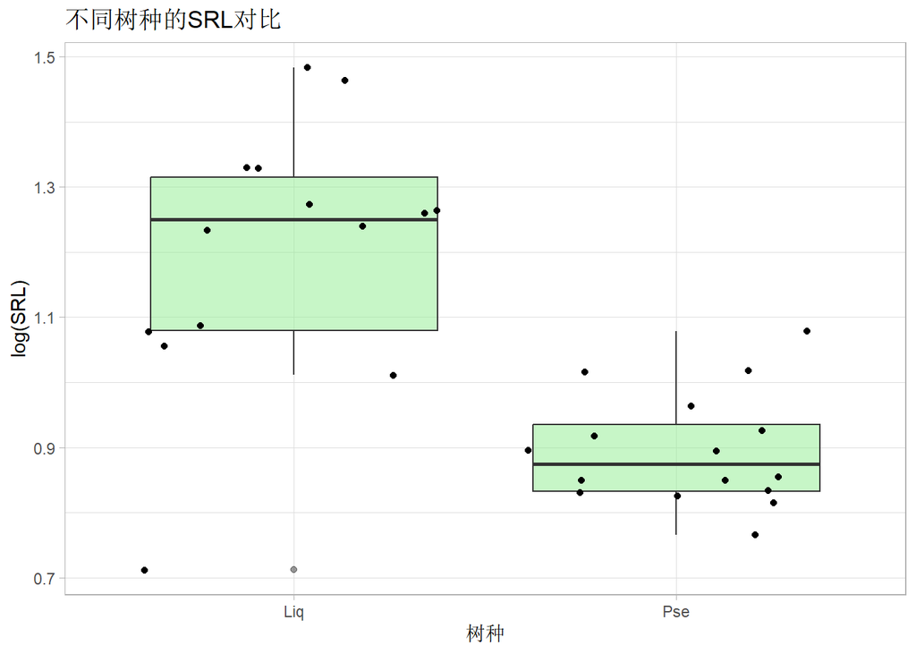

```
            Df Sum Sq Mean Sq F value   Pr(>F)
species      1 0.6976  0.6976   30.86 6.09e-06 ***
Residuals   28 0.6329  0.0226
---
Signif. codes:  0 '***' 0.001 '**' 0.01 '*' 0.05 '.' 0.1 ' ' 1
```

```r
aov_srl <- aov(SRL_log ~ species, data = root)
summary(aov_srl)
#其他指标类似
#aov_avgdiam <- aov(AvgDiam_log ~ species, data = root)
#aov_rtd <- aov(RTD_log ~ species, data = root)
#aov_sra <- aov(SRA_log ~ species, data = root)
ggplot(root, aes(x = species, y = SRL_log)) +
  geom_boxplot(fill="lightgreen",alpha=0.5) +
  geom_jitter() +
  labs(title = "不同树种的SRL对比", y = "log(SRL)", x = "树种") +
  theme_light()
```

两个树种的比根长（SRL）存在极显著差异（p<0.001）。

### 散点图

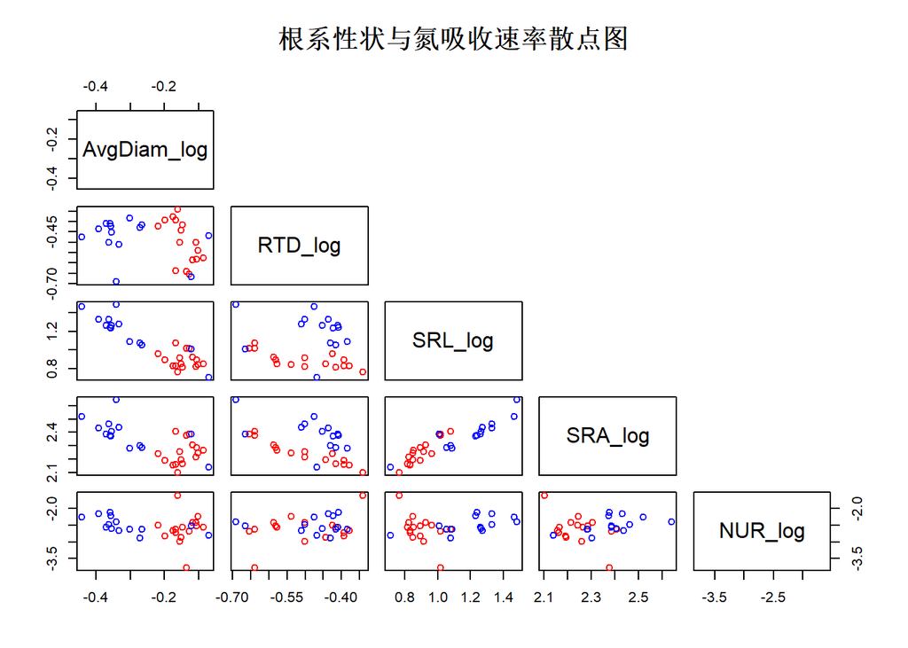

```r
pairs(root[, c("AvgDiam_log", "RTD_log", "SRL_log", "SRA_log", "NUR_log")],
      col = c("blue", "red")[root$species],
      upper.panel = NULL,
      main = "根系性状与氮吸收速率散点图")
```

AvgDiam、SRL、SRA三者之间有明显线性关系。

### Pearson相关性矩阵

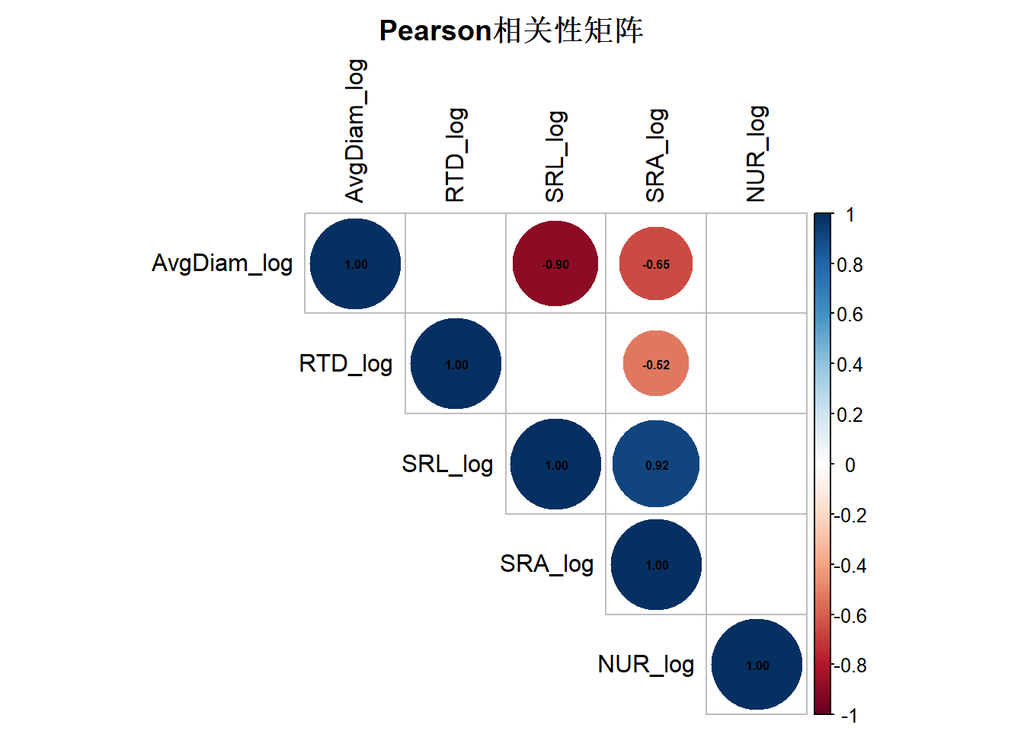

```r
library(corrplot)
cor_var <- select(root, AvgDiam_log, RTD_log, SRL_log, SRA_log, NUR_log)
cor_res <- cor(cor_var)
cor_p <- cor.mtest(cor_var, conf.level = 0.95)$p
corrplot(cor_res, type = "upper",
         p.mat = cor_p, sig.level = 0.05, insig = "blank",
         number.cex = 0.5,
         addCoef.col = "black", tl.col = "black",
         title = "Pearson相关性矩阵",
         mar = c(0,0,2,0))
```

比根长SRL与比根面积SRA呈显著正相关，平均直径AvgDiam与SRL、SRA呈显著负相关；各单一根系性状与氮吸收速率NUR无显著的线性关系。

### 线性回归

```r
#全模型
model_full <- lm(NUR_log ~ AvgDiam_log+RTD_log+SRL_log+SRA_log+species,
                 data = root)
summary(model_full)
```

```
Call:
lm(formula = NUR_log ~ AvgDiam_log + RTD_log + SRL_log + SRA_log +
    species, data = root)

Residuals:
     Min       1Q   Median       3Q      Max
-0.98238 -0.18044  0.02036  0.18774  0.85575

Coefficients:
              Estimate Std. Error t value Pr(>|t|)
(Intercept) -2.611e+03  4.909e+03  -0.532    0.600
AvgDiam_log -1.711e+03  3.289e+03  -0.520    0.608
RTD_log      1.649e+01  1.986e+01   0.830    0.415
SRL_log     -1.726e+03  3.284e+03  -0.526    0.604
SRA_log      1.742e+03  3.279e+03   0.531    0.600
speciesPse   8.825e-03  2.132e-01   0.041    0.967

Residual standard error: 0.3619 on 24 degrees of freedom
Multiple R-squared:  0.1591,    Adjusted R-squared:  -0.01603
F-statistic: 0.9085 on 5 and 24 DF,  p-value: 0.492
```

纳入所有变量的线性回归模型不显著。

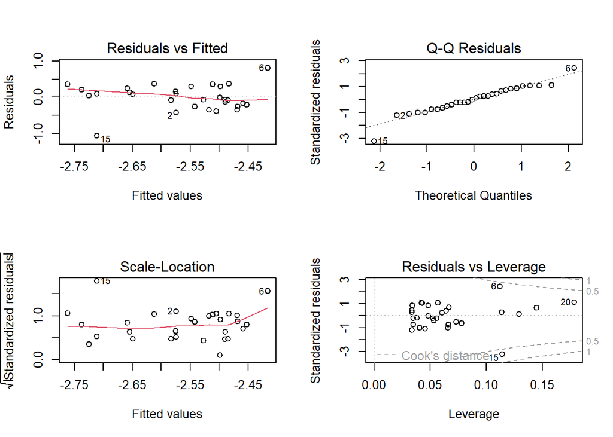

```
Start:  AIC=-55.67
NUR_log ~ AvgDiam_log + RTD_log + SRL_log + SRA_log + species

              Df Sum of Sq    RSS     AIC
- species      1  0.000224 3.1442 -57.669
- AvgDiam_log  1  0.035453 3.1794 -57.335
- SRL_log      1  0.036185 3.1802 -57.328
- SRA_log      1  0.036950 3.1809 -57.321
- RTD_log      1  0.090286 3.2343 -56.822
<none>                     3.1440 -55.671

Step:  AIC=-57.67
NUR_log ~ AvgDiam_log + RTD_log + SRL_log + SRA_log

              Df Sum of Sq    RSS     AIC
- AvgDiam_log  1  0.036326 3.1805 -59.324
- SRL_log      1  0.037077 3.1813 -59.317
- SRA_log      1  0.037865 3.1821 -59.310
- RTD_log      1  0.096011 3.2402 -58.767
<none>                     3.1442 -57.669
+ species      1  0.000224 3.1440 -55.671

Step:  AIC=-59.32
NUR_log ~ RTD_log + SRL_log + SRA_log

              Df Sum of Sq    RSS     AIC
- SRL_log      1  0.108519 3.2891 -60.318
- SRA_log      1  0.113170 3.2937 -60.276
- RTD_log      1  0.127555 3.3081 -60.145
<none>                     3.1805 -59.324
+ AvgDiam_log  1  0.036326 3.1442 -57.669
+ species      1  0.001097 3.1794 -57.335

Step:  AIC=-60.32
NUR_log ~ RTD_log + SRA_log

              Df Sum of Sq    RSS     AIC
- SRA_log      1   0.17691 3.4660 -60.746
<none>                     3.2891 -60.318
+ SRL_log      1   0.10852 3.1805 -59.324
```

[output cut: 17 more lines]

```

Residuals:
     Min       1Q   Median       3Q      Max
-1.06538 -0.20261  0.01783  0.23300  0.80929

Coefficients:
            Estimate Std. Error t value Pr(>|t|)
(Intercept)  -2.0793     0.3318  -6.267 8.95e-07 ***
RTD_log       0.9883     0.6654   1.485    0.149
---
Signif. codes:  0 '***' 0.001 '**' 0.01 '*' 0.05 '.' 0.1 ' ' 1

Residual standard error: 0.3518 on 28 degrees of freedom
Multiple R-squared:  0.07303,   Adjusted R-squared:  0.03993
F-statistic: 2.206 on 1 and 28 DF,  p-value: 0.1486
```

```r
#逐步回归法选择变量
model_step <- step(model_full, direction = "both")
summary(model_step)
par(mfrow = c(2,2))
plot(model_step)
```

逐步回归法最终模型仅包含**根组织密度（RTD_log）**，但该单变量模型不显著。

### 主成分分析（PCA）

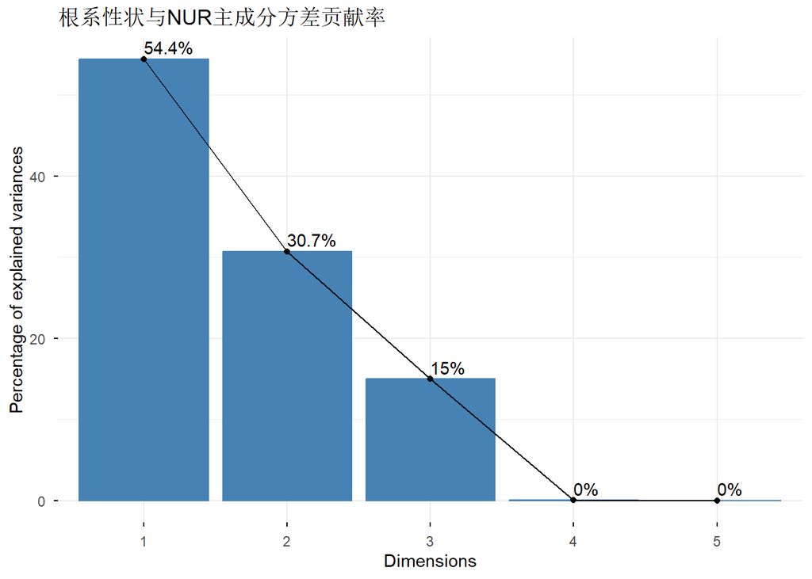

```r
library(FactoMineR)
library(factoextra)
pca_data <- root[, c("AvgDiam_log","RTD_log","SRL_log","SRA_log","NUR_log")]
pca_result <- PCA(pca_data,graph = FALSE)

fviz_eig(pca_result, addlabels = TRUE, title = "根系性状与NUR主成分方差贡献率")
```

前两个主成分共同解释85.1%的变异。

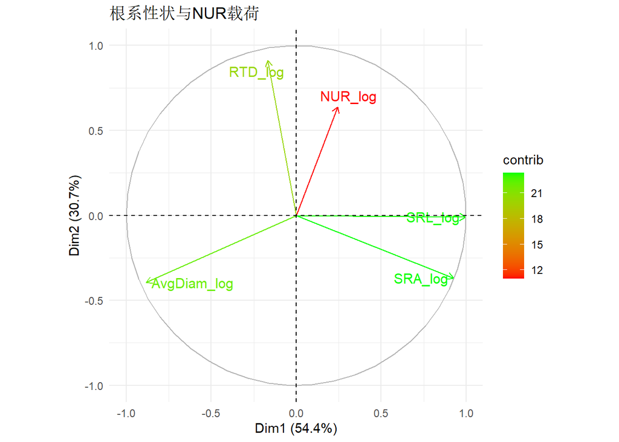

```r
fviz_pca_var(pca_result,
             col.var = "contrib",
             gradient.cols = c("red", "green"),
             repel = TRUE,
             title = "根系性状与NUR载荷")+   theme_minimal()
```

PC1由SRL、SRA（正相关）、AvgDiam（负相关）主导，PC2由RTD主导，NUR的贡献度较低，NUR与RTD（夹角较小）呈正相关。

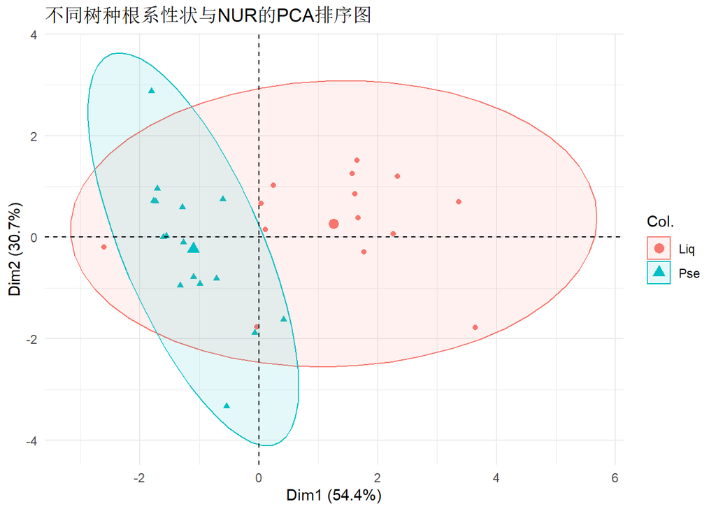

```r
fviz_pca_ind(pca_result,
             label = "none",
             col.ind  = root$species,
             addEllipses = TRUE,
             title = "不同树种根系性状与NUR的PCA排序图")+
  theme_minimal()
```

两个树种（Liq与Pse）的95%置信椭圆存在较大重叠，根系性状整体区分不明显。

# MaxEnt预测适生区

```r
library(biomod2)
library(terra)
species_points <- read_excel("./Data/species.xlsx")
env_stack <- rast(c("./Data/bio2.tif","./Data/bio3.tif","./Data/bio14.tif","./Data/bio15.tif","./Data/elev.tif"))
names(env_stack) <- c("bio2", "bio3", "bio14", "bio15", "elev")
```

### 生成背景点

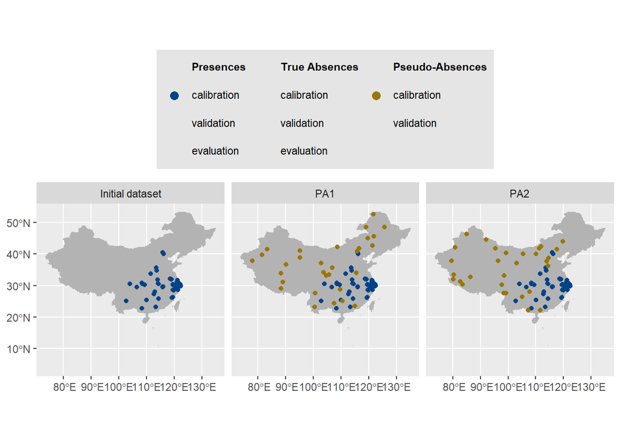

```r
PT_data <- BIOMOD_FormatingData(
  resp.name = "SDM_sample",
  resp.var = rep(1, nrow(species_points)),
  resp.xy = species_points,
  expl.var = env_stack,
  PA.nb.rep = 2,
  PA.nb.absences = 30,
  PA.strategy = 'random')
species_plot <- plot(PT_data)
```

生成2组伪不存在点，每组30个。

### 建模和评估（MAXNET）

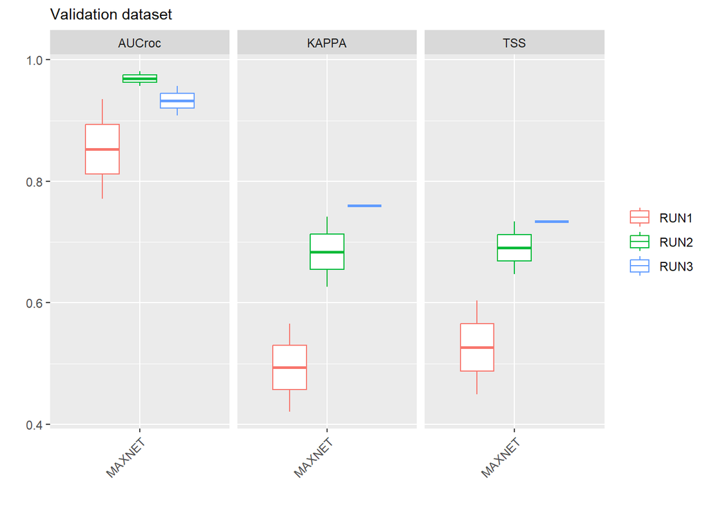

```r
PT_Model <- BIOMOD_Modeling(
  bm.format = PT_data,
  models = "MAXNET",
  CV.strategy = 'random',
  CV.nb.rep = 3,
  CV.perc = 0.7,
  OPT.strategy = 'bigboss',
  var.import = 3)
eval_plot <- bm_PlotEvalBoxplot(
  bm.out = PT_Model,
  dataset = 'validation',
  group.by = c('algo','run'))
```

AUC取值范围[0.5,1]，KAPPA、TSS取值范围[-1,1]，值越大模型拟合效果越好。

### 变量重要性（柱状图）

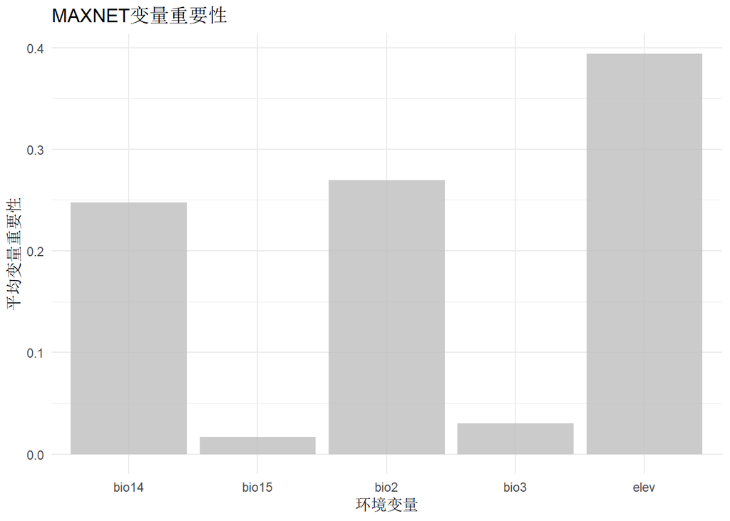

```r
var_imp <- get_variables_importance(PT_Model)
var_imp_grouped <- group_by(var_imp, expl.var)
var_imp_mean <- summarise(var_imp_grouped, mean_imp = mean(var.imp))
ggplot(var_imp_mean, aes(x = expl.var,y = mean_imp)) +
  geom_col(fill = "gray",alpha=0.8) +
  labs(x = "环境变量", y = "平均变量重要性",
       title = "MAXNET变量重要性") +
  theme_minimal()
```

**bio2（平均昼夜温差）、海拔**是影响该物种适生区的核心环境因子。

### 响应曲线

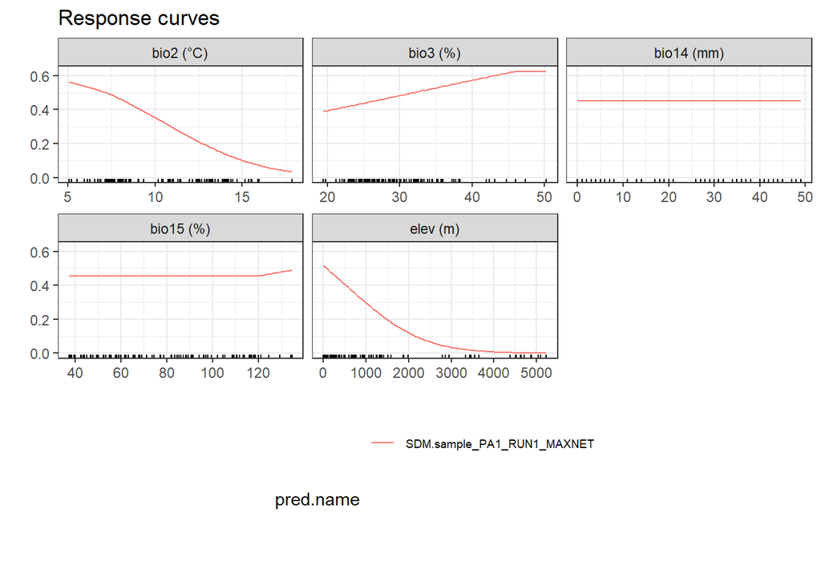

```r
resp <-bm_PlotResponseCurves(
  bm.out = PT_Model,
  models.chosen = 'SDM.sample_PA1_RUN1_MAXNET',
  fixed.var = 'median',
  do.plot = FALSE,
  main="Response curves")
resp$plot +
  theme_bw()+
  theme(legend.position = "bottom",
        legend.text = element_text(size = 7))+
  facet_wrap(
    ~expl.name,
    scales = "free_x",
    labeller = labeller(
      expl.name = function(x) {
        dplyr::case_when(
          x == "bio2"  ~ "bio2 (°C)",
          x == "bio3"  ~ "bio3 (%)",
          x == "bio14" ~ "bio14 (mm)",
          x == "bio15" ~ "bio15 (%)",
          x == "elev" ~ "elev (m)",
          TRUE ~ x        )      }  ) )+
  guides(colour = guide_legend(nrow = 4))
```

平均昼夜温差bio2达到7.5℃以上时，适生概率降至0.5以下。

### 适生区空间分布

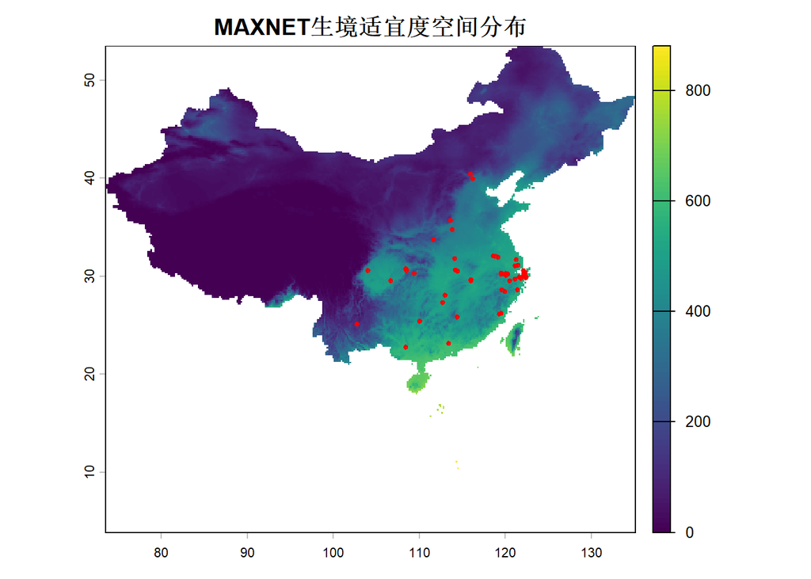

```r
myProj <- BIOMOD_Projection(
  bm.mod = PT_Model,
  proj.name = "Current",
  new.env = env_stack,
  models.chosen = "SDM.sample_PA1_RUN1_MAXNET",#考虑计算效率
  build.clamping.mask = FALSE
)
pred <- get_predictions(myProj)
plot(pred, main = "MAXNET生境适宜度空间分布")
points(species_points, pch = 10, cex = 0.5, col = "red")
```

生境适宜度的空间分布情况，红色点为物种分布点，高适生区集中在中国东南部。

# 野外样方

### 物种累积曲线

```r
library(vegan)
SAC <- read_excel("20sites.xlsx")
SAC=SAC[,-1]
head(SAC)
```

```
# A tibble: 6 × 86
  凹叶厚朴 八角枫 豹皮樟 糙叶树 臭辣树  刺槐 大果山胡椒 大戟科 大叶冬青  冬青
     <dbl>  <dbl>  <dbl>  <dbl>  <dbl> <dbl>      <dbl>  <dbl>    <dbl> <dbl>
1        0      0      0      0      0     0          0      0        0     0
2        0      0      0      3      0     0          0      0        0     0
3        0      2      0      0      0     0          0      1        0     0
4        0      0      0      0      0     0          0      0        0     0
5        0      2      0      0      0     1          0      0        0     2
6        0      0      1      1      0     0          0      0        0     0
# ℹ 76 more variables: 杜鹃花 <dbl>, 杜仲 <dbl>, 短柄枹 <dbl>, 短梗稠李 <dbl>,
#   短尾柯 <dbl>, 榧树 <dbl>, 枫香 <dbl>, 枫香树 <dbl>, 构树 <dbl>,
#   红果钓樟 <dbl>, 红果榆 <dbl>, 红楠 <dbl>, 湖北鹅耳枥 <dbl>, 花叶青木 <dbl>,
#   华女贞 <dbl>, 华山矾 <dbl>, 化香 <dbl>, 黄果朴 <dbl>, 黄山木兰 <dbl>,
#   黄檀 <dbl>, 灰白蜡瓣花 <dbl>, 鸡爪槭 <dbl>, 继木 <dbl>, 尖萼白蜡树 <dbl>,
#   建始槭 <dbl>, 金钱松 <dbl>, 苦槠 <dbl>, 乐思绣球 <dbl>, 楝树 <dbl>,
#   亮叶水青冈 <dbl>, 领春木 <dbl>, 柳杉 <dbl>, 栾树 <dbl>, 络石 <dbl>, …
```

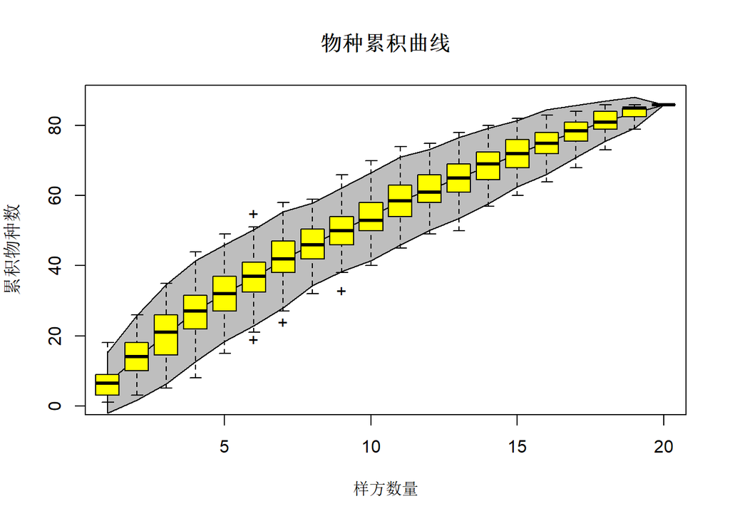

```r
sp <- specaccum(SAC, method="random")
plot(sp,ci.type="poly",ci.col="gray",ylab="累积物种数",xlab="样方数量",main="物种累积曲线")
boxplot(sp, col="yellow", add=TRUE, pch="+")
```

数据包含20个样方，累积物种数持续增加，未观察到平缓状态，样方数量有待增加。

### 物种丰度热图

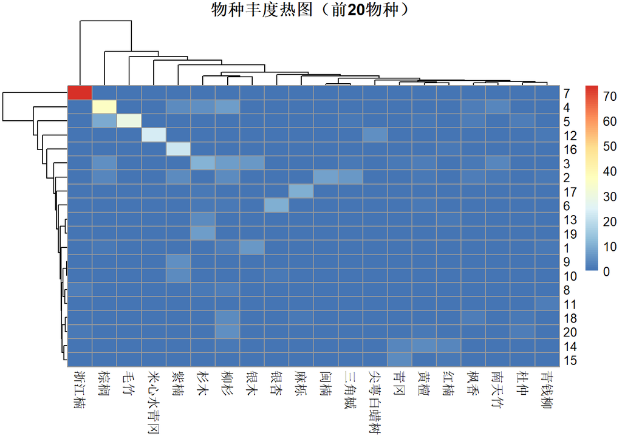

```r
library(pheatmap)
com <- read_excel("20sites.xlsx")
com <- com[, -1]
com_top <- com[, order(colSums(com), decreasing = TRUE)[1:20]]#按丰度排序
pheatmap(com_top,
         main = "物种丰度热图（前20物种）")
```

前20个物种的丰度分布情况：浙江楠在样方中为绝对优势种，棕榈丰度也较高。

### 丰度等级曲线

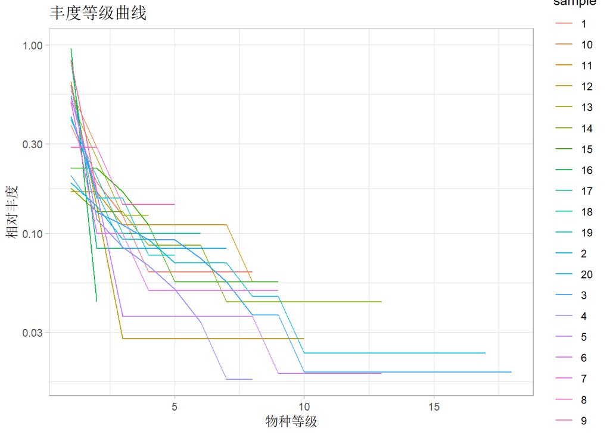

```r
com_relative <- com / rowSums(com)#相对丰度
rank_list <- lapply(1:20, function(i) {
  abund_vec <- as.numeric(com_relative[i, ])
  abund <- abund_vec[abund_vec > 0]
  sorted_abund <- sort(abund, decreasing = TRUE)
  df <- data.frame(
    rank = 1:length(sorted_abund),
    abundance = sorted_abund,
    sample = rownames(com_relative)[i]
  )
})
rank_dat <- do.call(rbind, rank_list)
ggplot(rank_dat, aes(x = rank, y = abundance, group = sample, color = sample)) +
  geom_line() +
  scale_y_log10() +
  labs(x = "物种等级", y = "相对丰度", title = "丰度等级曲线") +
  theme_light()
```

物种的相对丰度与等级的关系：所有样方的曲线都先快速下降后趋于平缓，即少量物种占据绝大部分的个体数量。

### CCA排序图

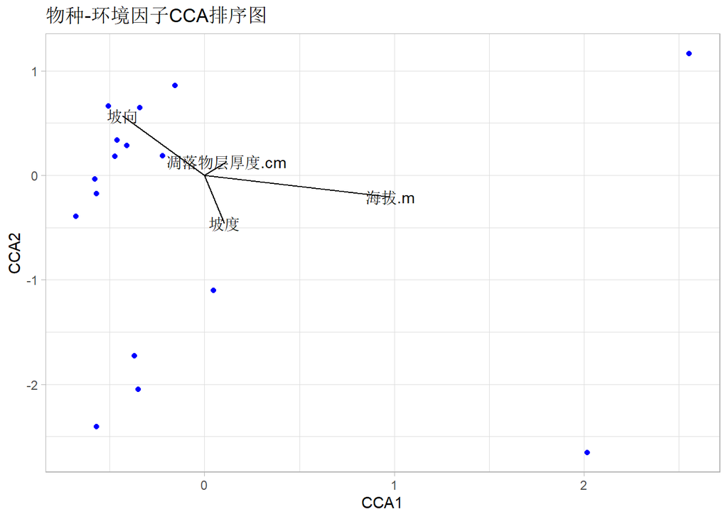

```r
env <- read.csv("环境因子.csv")
env_complete <- na.omit(env[, c("海拔.m", "凋落物层厚度.cm", "坡度", "坡向")])
com_complete <- com[rownames(com) %in% rownames(env_complete), ]
result <- cca(com_complete, env_complete)
site_scores <- scores(result, display = "sites")
env_vectors <- scores(result, display = "bp")
cca_sites <- data.frame(site_scores, sample = rownames(site_scores))
cca_env <- data.frame(env_vectors, label = rownames(env_vectors))
ggplot(cca_sites, aes(x = CCA1, y = CCA2)) +
  geom_point(color = "blue") +
  geom_segment(data = cca_env,
               aes(x = 0, y = 0, xend = CCA1, yend = CCA2)) +
  geom_text(data = cca_env,
            aes(label = label)) +
  labs(title = "物种-环境因子CCA排序图") +
  theme_light()
```

海拔是影响物种组成的最主要因子，沿CCA1正方向作用，坡向主要作用于CCA2正方向。左上角集中的样方物种组成较为相似，与坡向箭头方向一致，物种组成主要受坡向影响